# Ch 7 The Linear Model

# Simple linear regression

```r
library(fpp3)
```

```r
str(us_change)
```

```
tbl_ts [198 × 6] (S3: tbl_ts/tbl_df/tbl/data.frame)
 $ Quarter     : qtr [1:198] 1970 Q1, 1970 Q2, 1970 Q3, 1970 Q4, 1971 Q1, 1971 Q2, 1971 Q3,...
 $ Consumption : num [1:198] 0.619 0.452 0.873 -0.272 1.901 ...
 $ Income      : num [1:198] 1.04 1.23 1.59 -0.24 1.98 ...
 $ Production  : num [1:198] -2.452 -0.551 -0.359 -2.186 1.91 ...
 $ Savings     : num [1:198] 5.3 7.79 7.4 1.17 3.54 ...
 $ Unemployment: num [1:198] 0.9 0.5 0.5 0.7 -0.1 ...
 - attr(*, "key")= tibble [1 × 1] (S3: tbl_df/tbl/data.frame)
  ..$ .rows: list<int> [1:1]
  .. ..$ : int [1:198] 1 2 3 4 5 6 7 8 9 10 ...
  .. ..@ ptype: int(0)
 - attr(*, "index")= chr "Quarter"
  ..- attr(*, "ordered")= logi TRUE
 - attr(*, "index2")= chr "Quarter"
 - attr(*, "interval")= interval [1:1] 1Q
  ..@ .regular: logi TRUE
```

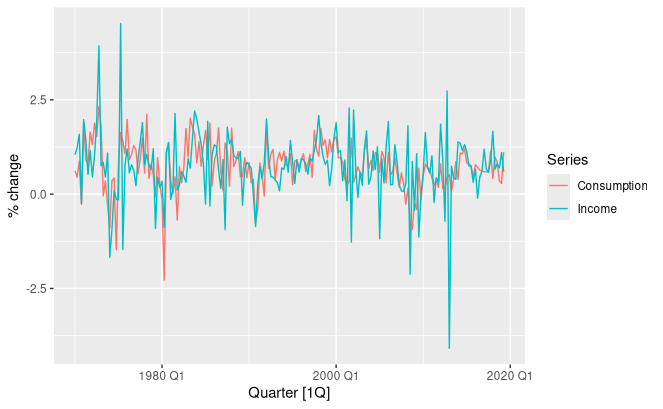

```r
us_change |>
  pivot_longer(c(Consumption, Income), names_to = "Series") |>
  autoplot(value) +
  labs(y = "% change")
```

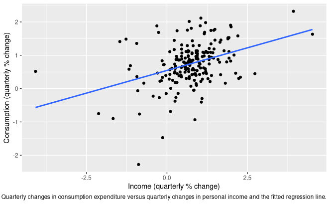

```r
us_change |>
  ggplot(aes(x = Income, y = Consumption)) +
  labs(y = "Consumption (quarterly % change)",
       x = "Income (quarterly % change)",
       caption = "Quarterly changes in consumption expenditure versus quarterly changes in personal income and the fitted regression line.") +
  geom_point() +
  geom_smooth(method = "lm", se = FALSE)
```

```r
us_change |>
  model(TSLM(Consumption ~ Income)) |>
  report()
```

[output not shown]

# Multiple linear regression

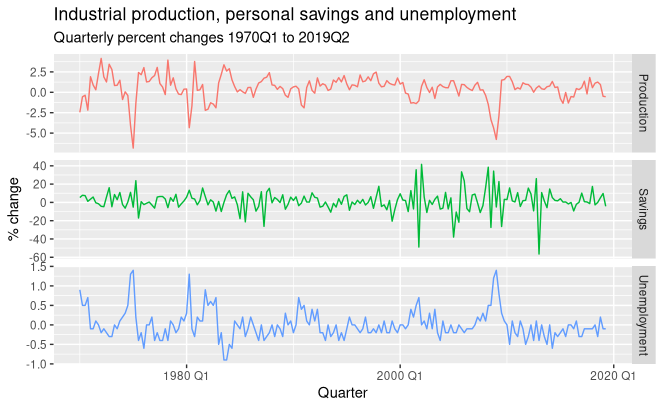

```r
us_change |>
  select(-Consumption, -Income) |>
  pivot_longer(-Quarter) |>
  ggplot(aes(Quarter, value, color = name)) +
  geom_line() +
  facet_grid(name ~ ., scales = "free_y") +
  guides(color = "none") +
  labs(y = "% change",
       title = "Industrial production, personal savings and unemployment",
       subtitle = "Quarterly percent changes 1970Q1 to 2019Q2"
       )
```

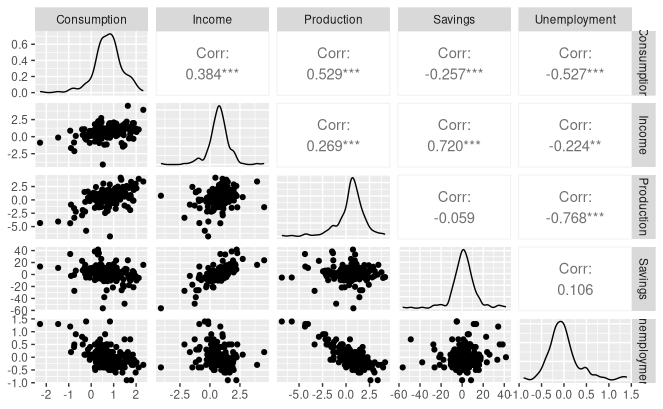

```r
us_change |>
  GGally::ggpairs(columns = 2:6)
```

## Assumptions

First, we assume that the model is a reasonable approximation to reality; that is, the relationship between the forecast variable and the predictor variables satisfies this linear equation.

Second, we make the following assumptions about the errors $(\varepsilon_{1},\dots,\varepsilon_{T})$:

- they have mean zero; otherwise the forecasts will be systematically biased.
- they are not autocorrelated; otherwise the forecasts will be inefficient, as there is more information in the data that can be exploited.
- they are unrelated to the predictor variables; otherwise there would be more information that should be included in the systematic part of the model.

It is also useful to have the errors being normally distributed with a constant variance $\sigma^2$ in order to easily produce prediction intervals.

Another important assumption in the linear regression model is that each predictor $x$ is not a random variable. If we were performing a controlled experiment in a laboratory, we could control the values of each $x$ (so they would not be random) and observe the resulting values of $y$. With observational data (including most data in business and economics), it is not possible to control the value of $x$, we simply observe it. Hence we make this an assumption.

# Least squares

## Example: US consumption expenditure

```r
fit_consMR <- us_change |>
  model(tslm = TSLM(Consumption ~ Income + Production +
                      Unemployment + Savings))
report(fit_consMR)
```

```
Series: Consumption
Model: TSLM

Residuals:
     Min       1Q   Median       3Q      Max
-0.90555 -0.15821 -0.03608  0.13618  1.15471

Coefficients:
              Estimate Std. Error t value Pr(>|t|)
(Intercept)   0.253105   0.034470   7.343 5.71e-12 ***
Income        0.740583   0.040115  18.461  < 2e-16 ***
Production    0.047173   0.023142   2.038   0.0429 *
Unemployment -0.174685   0.095511  -1.829   0.0689 .
Savings      -0.052890   0.002924 -18.088  < 2e-16 ***
---
Signif. codes:  0 ‘***’ 0.001 ‘**’ 0.01 ‘*’ 0.05 ‘.’ 0.1 ‘ ’ 1

Residual standard error: 0.3102 on 193 degrees of freedom
Multiple R-squared: 0.7683, Adjusted R-squared: 0.7635
F-statistic:   160 on 4 and 193 DF, p-value: < 2.22e-16
```

For forecasting purposes, the final two columns are of limited interest. The “t value” is the ratio of an estimated $\beta$ coefficient to its standard error and the last column gives the p-value: the probability of the estimated $\beta$ coefficient being as large as it is if there was no real relationship between consumption and the corresponding predictor. This is useful when studying the effect of each predictor, but is not particularly useful for forecasting.

## Fitted values

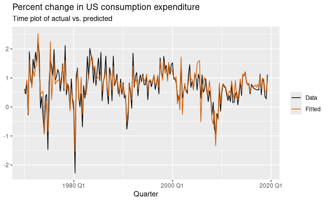

```r
augment(fit_consMR) |>
  ggplot(aes(x = Quarter)) +
  geom_line(aes(y = Consumption, colour = "Data")) +
  geom_line(aes(y = .fitted, colour = "Fitted")) +
  labs(y = NULL,
       title = "Percent change in US consumption expenditure",
       subtitle = "Time plot of actual vs. predicted") +
  scale_colour_manual(values = c(Data = "black", Fitted = "#D55E00")) +
  guides(colour = guide_legend(title = NULL))
```

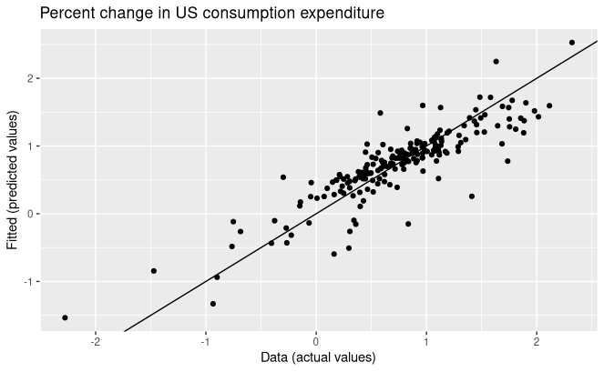

```r
augment(fit_consMR) |>
  ggplot(aes(Consumption, .fitted)) +
  geom_point() +
  labs(
    y = "Fitted (predicted values)",
    x = "Data (actual values)",
    title = "Percent change in US consumption expenditure"
  ) +
  geom_abline(intercept = 0, slope = 1)
```

# Evaluating the regression model

## Histogram of residuals

[figure not shown]

```r
augment(fit_consMR) |>
  features(.innov, ljung_box, lag = 10) |> print.AsIs()
```

```
  .model  lb_stat  lb_pvalue
1   tslm 18.86532 0.04200702
```

## Residual plots against predictors

Should show no pattern

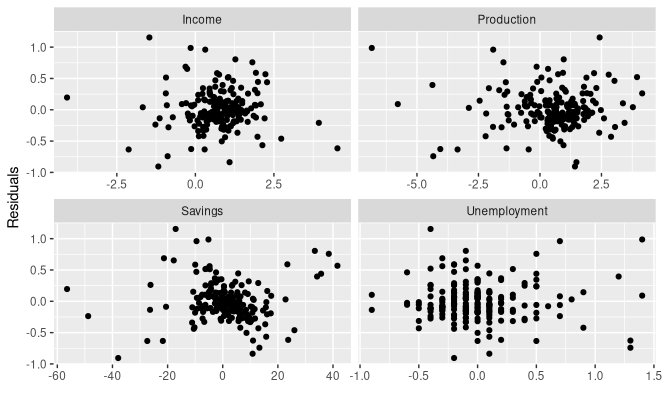

## Residual plots against fitted values

Should also show no pattern, otherwise heterodastic, consider log or sqrt.

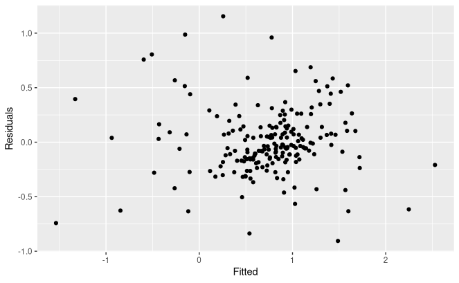

```r
augment(fit_consMR) |>
  ggplot(aes(.fitted, .resid)) +
  geom_point() +
  labs(x = "Fitted", y = "Residuals")
```

## Outliers and influential observations

Usually influential observations are outliers but not all outliers are influential.

Outliers can simply be data entry errors. In any case, explore…

If outliers are real and influential, report results both including and including.

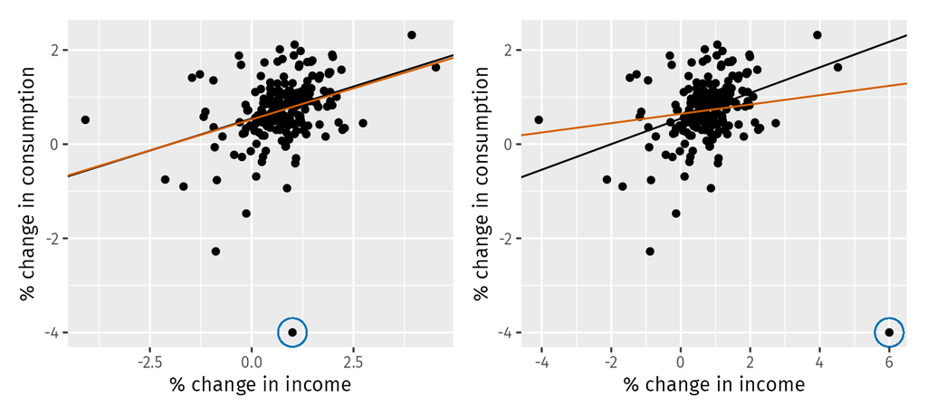

The effect of outliers and influential observations on regression

## Spurious regression

Time series are generally non-stationary, and can seem to be correlated to unrelated variables. High $R^2$ and high residual autocorrelation can be signs of spurious regression.

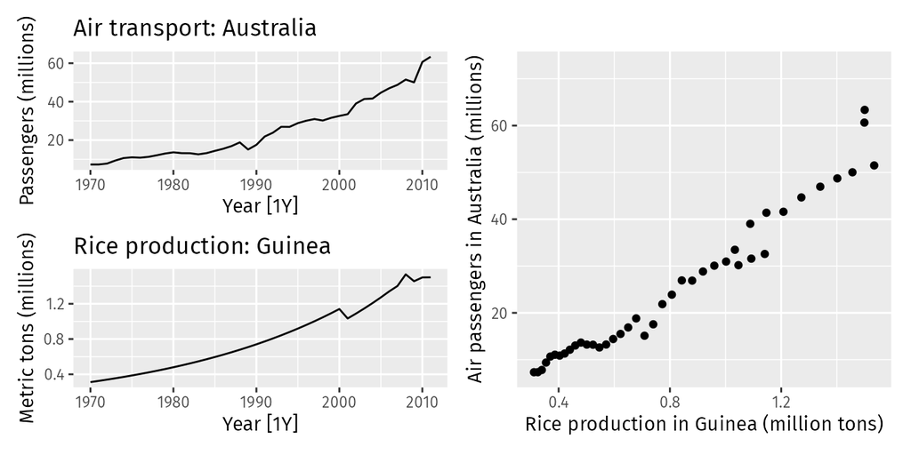

Trending time series data can appear to be related, as shown in this example where air passengers in Australia are regressed against rice production in Guinea.

```r
fit <- aus_airpassengers |>
  filter(Year <= 2011) |>
  left_join(guinea_rice, by = "Year") |>
  model(TSLM(Passengers ~ Production))
report(fit)
```

```
Series: Passengers
Model: TSLM

Residuals:
    Min      1Q  Median      3Q     Max
-5.9448 -1.8917 -0.3272  1.8620 10.4210

Coefficients:
            Estimate Std. Error t value Pr(>|t|)
(Intercept)   -7.493      1.203  -6.229 2.25e-07 ***
Production    40.288      1.337  30.135  < 2e-16 ***
---
Signif. codes:  0 ‘***’ 0.001 ‘**’ 0.01 ‘*’ 0.05 ‘.’ 0.1 ‘ ’ 1

Residual standard error: 3.239 on 40 degrees of freedom
Multiple R-squared: 0.9578, Adjusted R-squared: 0.9568
F-statistic: 908.1 on 1 and 40 DF, p-value: < 2.22e-16
```

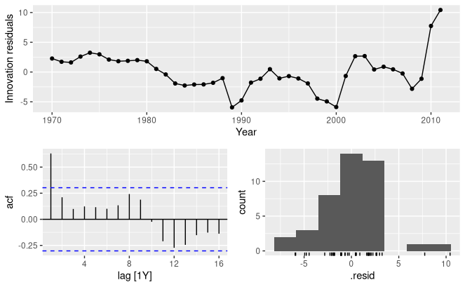

## Some useful predictors

- Trend
- Dummy variables
- Seasonal dummy variables
- Intervention variables

*Dummy variable trap*: include 1 less variable than possible results since any group only has n-1 dof.

### Example

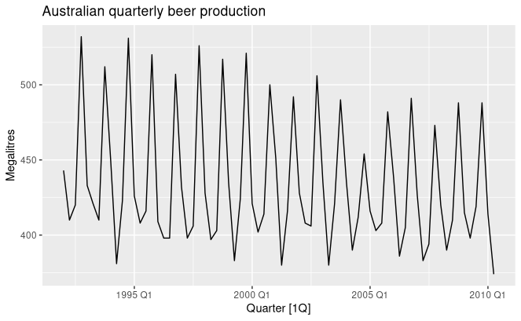

```r
recent_production <- aus_production |>
  filter(year(Quarter) >= 1992)
recent_production |>
  autoplot(Beer) +
  labs(y = "Megalitres",
       title = "Australian quarterly beer production")
```

```r
fit_beer <- recent_production |>
  model(TSLM(Beer ~ trend() + season()))
report(fit_beer)
```

```
Series: Beer
Model: TSLM

Residuals:
     Min       1Q   Median       3Q      Max
-42.9029  -7.5995  -0.4594   7.9908  21.7895

Coefficients:
               Estimate Std. Error t value Pr(>|t|)
(Intercept)   441.80044    3.73353 118.333  < 2e-16 ***
trend()        -0.34027    0.06657  -5.111 2.73e-06 ***
season()year2 -34.65973    3.96832  -8.734 9.10e-13 ***
season()year3 -17.82164    4.02249  -4.430 3.45e-05 ***
season()year4  72.79641    4.02305  18.095  < 2e-16 ***
---
Signif. codes:  0 ‘***’ 0.001 ‘**’ 0.01 ‘*’ 0.05 ‘.’ 0.1 ‘ ’ 1

Residual standard error: 12.23 on 69 degrees of freedom
Multiple R-squared: 0.9243, Adjusted R-squared: 0.9199
F-statistic: 210.7 on 4 and 69 DF, p-value: < 2.22e-16
```

Note that `trend()` and `season()` are not standard functions; they are “special” functions that work within the `TSLM()` model formulae.

There is an average downward trend of -0.34 megalitres per quarter. On average, the second quarter has production of 34.7 megalitres lower than the first quarter, the third quarter has production of 17.8 megalitres lower than the first quarter, and the fourth quarter has production of 72.8 megalitres higher than the first quarter.

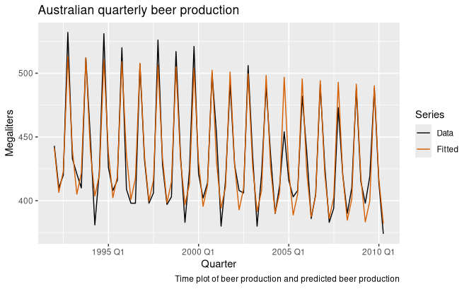

```r
augment(fit_beer) |>
  ggplot(aes(Quarter)) +
  geom_line(aes(y = Beer, colour = "Data")) +
  geom_line(aes(y = .fitted, colour = "Fitted")) +
  scale_colour_manual(
    values = c(Data = "black", Fitted = "#D55E00")
  ) +
  labs(y = "Megaliters",
       title = "Australian quarterly beer production",
       caption = "Time plot of beer production and predicted beer production") +
  guides(color = guide_legend(title = "Series"))
```

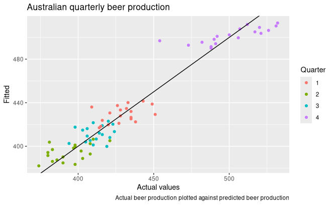

```r
augment(fit_beer) |>
  ggplot(aes(x = Beer, y = .fitted,
             colour = factor(quarter(Quarter)))) +
  geom_point() +
  labs(y = "Fitted", x = "Actual values",
       title = "Australian quarterly beer production",
       caption = "Actual beer production plotted against predicted beer production") +
  geom_abline(intercept = 0, slope = 1) +
  guides(colour = guide_legend(title = "Quarter"))
```

## Intervention variables

- spike: one-time
- step: change which becomes permanent

Trading days, distributed lags, Easter

## Fourier series

Alternative to seasonal dummy variables. If $m$ is seasonal:

$$x_{1,t} = \sin\left(\textstyle\frac{2\pi t}{m}\right),
x_{2,t} = \cos\left(\textstyle\frac{2\pi t}{m}\right),
x_{3,t} = \sin\left(\textstyle\frac{4\pi t}{m}\right),$$

$$x_{4,t} = \cos\left(\textstyle\frac{4\pi t}{m}\right),
x_{5,t} = \sin\left(\textstyle\frac{6\pi t}{m}\right),
x_{6,t} = \cos\left(\textstyle\frac{6\pi t}{m}\right),$$

With Fourier terms, we often need fewer predictors than with dummy variables, especially when $m$ is large. This makes them useful for weekly data, for example, where $m \approx 52$. For short seasonal periods (e.g., quarterly data), there is little advantage in using Fourier terms over seasonal dummy variables.

```r
fourier_beer <- recent_production |>
  model(TSLM(Beer ~ trend() + fourier(K = 2)))
report(fourier_beer)
```

```
Series: Beer
Model: TSLM

Residuals:
     Min       1Q   Median       3Q      Max
-42.9029  -7.5995  -0.4594   7.9908  21.7895

Coefficients:
                    Estimate Std. Error t value Pr(>|t|)
(Intercept)        446.87920    2.87321 155.533  < 2e-16 ***
trend()             -0.34027    0.06657  -5.111 2.73e-06 ***
fourier(K = 2)C1_4   8.91082    2.01125   4.430 3.45e-05 ***
fourier(K = 2)S1_4 -53.72807    2.01125 -26.714  < 2e-16 ***
fourier(K = 2)C2_4 -13.98958    1.42256  -9.834 9.26e-15 ***
---
Signif. codes:  0 ‘***’ 0.001 ‘**’ 0.01 ‘*’ 0.05 ‘.’ 0.1 ‘ ’ 1

Residual standard error: 12.23 on 69 degrees of freedom
Multiple R-squared: 0.9243, Adjusted R-squared: 0.9199
F-statistic: 210.7 on 4 and 69 DF, p-value: < 2.22e-16
```

The `K` argument to `fourier()` specifies how many pairs of sin and cos terms to include. The maximum allowed is $K=m/2$ where $m$ is the seasonal period. Because we have used the maximum here, the results are identical to those obtained when using seasonal dummy variables.

# Selecting predictors

```r
glance(fit_consMR) |>
  select(adj_r_squared, CV, AIC, AICc, BIC) |>
  print.AsIs()
```

```
  adj_r_squared        CV       AIC      AICc       BIC
1     0.7634805 0.1038972 -456.5799 -456.1401 -436.8503
```

- Adjusted $R^2$ - keeps $R^2$ from increasing just by increasing number of predictors
- Cross-validation - “leave-one-out” for each variable, then MSE
- Akaike’s Information Criterion - CV with penalty for additional predictors
- Corrected AIC - Correction for small values of $T$
- Schwarz’s Bayesian Information Criterion - penalizes number of parameters more heavily

Best for TSA: AICc, AIC or CV are best for forecasting.

- Best subset regression: where possible, test all possible subsets
- Stepwise regression:
  - backward starting with all potential predictors and drop least significant
  - forward adding one at a time and keeping the most significant
  - hybrid starting with a potential subset and testing both add/drop

**Beware inference after predictor selection!**